# R Notebook for calve hutches experiment

This is an [R Markdown](http://rmarkdown.rstudio.com) Notebook for Raf Van De Mierop his master thesis on switching the direction of calve hutches.

# Data import

```r
path <- "./Data.csv"
df.calves <- read.csv2(path)
summary(df.calves)
```

```
##      HUTCH         BOXFACTOR SWITCH      BEDDING           NOSE
##  Min.   : 1.00   Min.   :1   NO :32   Min.   :11.00   Min.   :0.0000
##  1st Qu.: 8.75   1st Qu.:1   YES:32   1st Qu.:22.00   1st Qu.:0.0000
##  Median :16.50   Median :1            Median :24.50   Median :0.0000
##  Mean   :16.50   Mean   :1            Mean   :24.16   Mean   :0.1875
##  3rd Qu.:24.25   3rd Qu.:1            3rd Qu.:28.25   3rd Qu.:0.0000
##  Max.   :32.00   Max.   :1            Max.   :36.00   Max.   :2.0000
##       EYES            COUGH             TEMP           GENERAL
##  Min.   :0.0000   Min.   :0.0000   Min.   :0.0000   Min.   :0.000
##  1st Qu.:0.0000   1st Qu.:0.0000   1st Qu.:1.0000   1st Qu.:1.000
##  Median :0.0000   Median :0.0000   Median :1.0000   Median :1.000
##  Mean   :0.1562   Mean   :0.1875   Mean   :0.9375   Mean   :1.469
##  3rd Qu.:0.0000   3rd Qu.:0.0000   3rd Qu.:1.0000   3rd Qu.:2.000
##  Max.   :1.0000   Max.   :2.0000   Max.   :2.0000   Max.   :5.000
##       AGE             FEED         TREATMENT        GENDER       SAMPLE
##  Min.   :14.00   Min.   :2.000   Min.   :0   vrouwelijk:64   Min.   :1.0
##  1st Qu.:28.00   1st Qu.:2.000   1st Qu.:0                   1st Qu.:1.0
##  Median :37.00   Median :3.000   Median :0                   Median :1.5
##  Mean   :36.19   Mean   :3.125   Mean   :0                   Mean   :1.5
##  3rd Qu.:47.00   3rd Qu.:4.000   3rd Qu.:0                   3rd Qu.:2.0
##  Max.   :53.00   Max.   :4.000   Max.   :0                   Max.   :2.0
##       CORR            CFU         CORR_SAMPLE
##  Min.   :12.00   Min.   :112.0   Min.   : 58.0
##  1st Qu.:23.00   1st Qu.:204.5   1st Qu.:161.5
##  Median :38.50   Median :292.0   Median :258.0
##  Mean   :37.16   Mean   :296.2   Mean   :259.1
##  3rd Qu.:48.25   3rd Qu.:374.0   3rd Qu.:340.0
##  Max.   :69.00   Max.   :592.0   Max.   :549.0
```

You can already clearly see that some of the variables are obsolete, all are females, so that factor is useless

Some transformations are needed

```r
df.calves$HUTCH <- as.factor(df.calves$HUTCH)
df.calves$SAMPLE <- as.factor(df.calves$SAMPLE)
```

# Data exploration

We next need to explore our data of interest visually, namely both CFU samples.

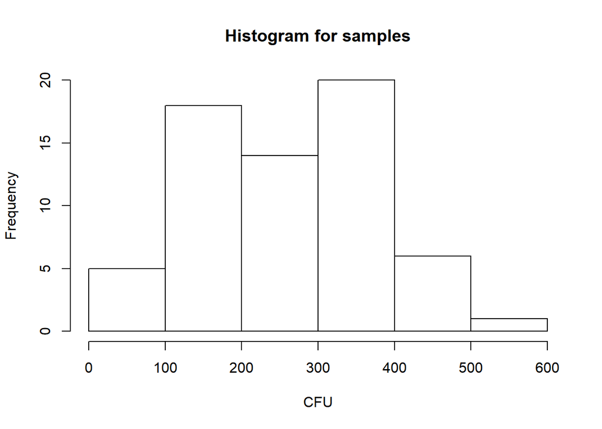

```r
hist(df.calves$CORR_SAMPLE,
     main = "Histogram for samples",
     xlab = "CFU")
```

So far it looks like the data is normally distributed when looking at the CFU.

# Influencers of the CFU

NEXT, let’s take a look whether the CFU is influenced by some of the measures taken while sampling. For example age of the calve.

## Model building

A [generalised linear model](https://en.wikipedia.org/wiki/Generalized_linear_model) is constructed with HUTCH as random effect.

First the baseline model is build, and next [univariate models](https://en.wikipedia.org/wiki/Univariate) are constructed for each of the variables.

```
## summary from lme4 is returned
## some computational error has occurred in lmerTest
```

```
## Linear mixed model fit by REML ['lmerMod']
## Formula: CFU ~ 1 + (1 | HUTCH)
##    Data: df.calves
##
## REML criterion at convergence: 777.8
##
## Scaled residuals:
##      Min       1Q   Median       3Q      Max
## -1.53926 -0.78339 -0.05291  0.68042  2.46406
##
## Random effects:
##  Groups   Name        Variance Std.Dev.
##  HUTCH    (Intercept)  1045     32.33
##  Residual             11618    107.78
## Number of obs: 64, groups:  HUTCH, 32
##
## Fixed effects:
##             Estimate Std. Error t value
## (Intercept)   296.25      14.64   20.24
```

This is the baseline model which can be subsequently used when adding explanatory variables.

### AGE

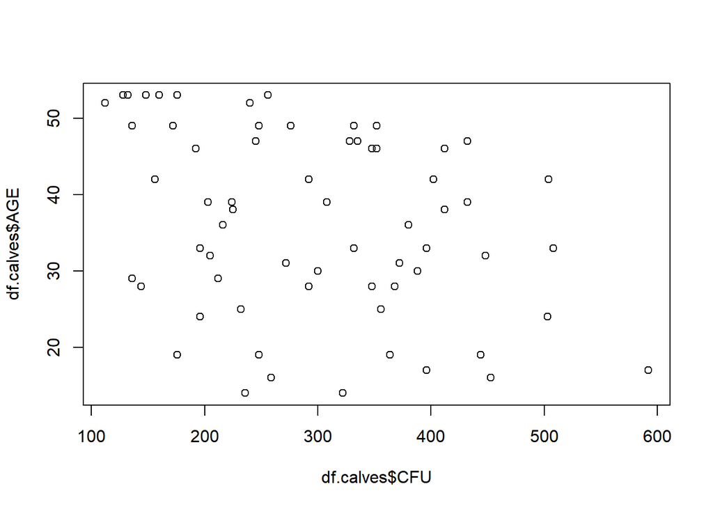

```r
plot(df.calves$CFU, df.calves$AGE)
```

```r
summary(glm1 <- lmer(CFU~ AGE +  (1|HUTCH),
                        df.calves))
```

```
## Linear mixed model fit by REML t-tests use Satterthwaite approximations
##   to degrees of freedom [lmerMod]
## Formula: CFU ~ AGE + (1 | HUTCH)
##    Data: df.calves
##
## REML criterion at convergence: 768.9
##
## Scaled residuals:
##      Min       1Q   Median       3Q      Max
## -1.69829 -0.90826  0.01284  0.76464  2.21360
##
## Random effects:
##  Groups   Name        Variance  Std.Dev.
##  HUTCH    (Intercept) 1.389e-10 1.179e-05
##  Residual             1.150e+04 1.072e+02
## Number of obs: 64, groups:  HUTCH, 32
##
## Fixed effects:
##             Estimate Std. Error      df t value Pr(>|t|)
## (Intercept)  406.343     42.938  62.000   9.463  1.2e-13 ***
## AGE           -3.042      1.127  62.000  -2.699  0.00895 **
## ---
## Signif. codes:  0 '***' 0.001 '**' 0.01 '*' 0.05 '.' 0.1 ' ' 1
##
## Correlation of Fixed Effects:
##     (Intr)
## AGE -0.950
```

```r
anova(baseline, glm1, test = "Chisq")
```

```
## refitting model(s) with ML (instead of REML)
```

|  | Df | AIC | BIC | logLik | deviance | Chisq | Chi Df | Pr(>Chisq) |
| --- | --- | --- | --- | --- | --- | --- | --- | --- |
| object | 3 | 790.9615 | 797.4381 | -392.4807 | 784.9615 | NA | NA | NA |
| ..1 | 4 | 785.9955 | 794.6310 | -388.9977 | 777.9955 | 6.965995 | 1 | 0.008307321 |

So it can be seen that age is influencing the CFU, but maybe this is due to the bedding?

### BEDDING

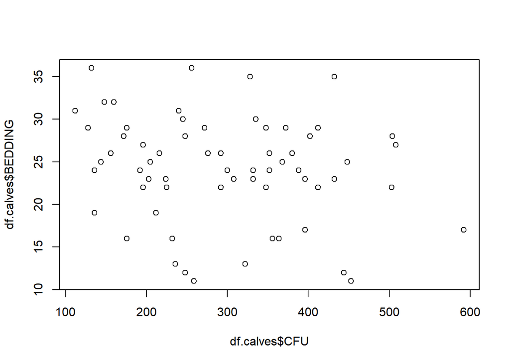

```r
plot(df.calves$CFU, df.calves$BEDDING)
```

```r
summary(glm2 <- lmer(CFU~ BEDDING + (1|HUTCH),
                        df.calves))
```

```
## Linear mixed model fit by REML t-tests use Satterthwaite approximations
##   to degrees of freedom [lmerMod]
## Formula: CFU ~ BEDDING + (1 | HUTCH)
##    Data: df.calves
##
## REML criterion at convergence: 772.1
##
## Scaled residuals:
##      Min       1Q   Median       3Q      Max
## -1.49670 -0.84995 -0.04057  0.74925  2.32046
##
## Random effects:
##  Groups   Name        Variance Std.Dev.
##  HUTCH    (Intercept)   793.4   28.17
##  Residual             11617.6  107.78
## Number of obs: 64, groups:  HUTCH, 32
##
## Fixed effects:
##             Estimate Std. Error      df t value Pr(>|t|)
## (Intercept)  380.180     58.586  30.000   6.489 3.58e-07 ***
## BEDDING       -3.474      2.351  30.000  -1.478     0.15
## ---
## Signif. codes:  0 '***' 0.001 '**' 0.01 '*' 0.05 '.' 0.1 ' ' 1
##
## Correlation of Fixed Effects:
##         (Intr)
## BEDDING -0.969
```

```r
anova(baseline, glm2, test = "Chisq")
```

```
## refitting model(s) with ML (instead of REML)
```

|  | Df | AIC | BIC | logLik | deviance | Chisq | Chi Df | Pr(>Chisq) |
| --- | --- | --- | --- | --- | --- | --- | --- | --- |
| object | 3 | 790.9615 | 797.4381 | -392.4807 | 784.9615 | NA | NA | NA |
| ..1 | 4 | 790.7132 | 799.3487 | -391.3566 | 782.7132 | 2.248291 | 1 | 0.1337621 |

We can see that the bedding is not a significant influencer.

### SWITCH

What about switching the direction of the hutch.

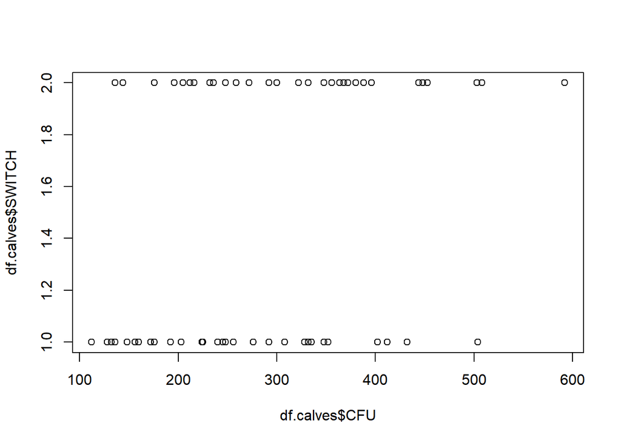

```r
plot(df.calves$CFU, df.calves$SWITCH)
```

```r
summary(glm3 <- lmer(CFU~ SWITCH + (1|HUTCH),
                        df.calves))
```

```
## Linear mixed model fit by REML t-tests use Satterthwaite approximations
##   to degrees of freedom [lmerMod]
## Formula: CFU ~ SWITCH + (1 | HUTCH)
##    Data: df.calves
##
## REML criterion at convergence: 766.1
##
## Scaled residuals:
##      Min       1Q   Median       3Q      Max
## -1.59528 -0.82194 -0.03131  0.60401  2.36143
##
## Random effects:
##  Groups   Name        Variance Std.Dev.
##  HUTCH    (Intercept)   590.5   24.3
##  Residual             11617.6  107.8
## Number of obs: 64, groups:  HUTCH, 32
##
## Fixed effects:
##             Estimate Std. Error     df t value Pr(>|t|)
## (Intercept)   270.94      20.00  30.00   13.55 2.53e-14 ***
## SWITCHYES      50.62      28.28  30.00    1.79   0.0836 .
## ---
## Signif. codes:  0 '***' 0.001 '**' 0.01 '*' 0.05 '.' 0.1 ' ' 1
##
## Correlation of Fixed Effects:
##           (Intr)
## SWITCHYES -0.707
```

```r
anova(baseline, glm3, test = "Chisq")
```

```
## refitting model(s) with ML (instead of REML)
```

|  | Df | AIC | BIC | logLik | deviance | Chisq | Chi Df | Pr(>Chisq) |
| --- | --- | --- | --- | --- | --- | --- | --- | --- |
| object | 3 | 790.9615 | 797.4381 | -392.4807 | 784.9615 | NA | NA | NA |
| ..1 | 4 | 789.7144 | 798.3499 | -390.8572 | 781.7144 | 3.247118 | 1 | 0.07154915 |

And a tendency for an effect of switching the direction of the hutch.

## Final model

Lets build the final model by adding an interaction between both

```r
summary(glm4 <- lmer(CFU~ SWITCH * AGE + (1|HUTCH),
                        df.calves))
```

```
## Linear mixed model fit by REML t-tests use Satterthwaite approximations
##   to degrees of freedom [lmerMod]
## Formula: CFU ~ SWITCH * AGE + (1 | HUTCH)
##    Data: df.calves
##
## REML criterion at convergence: 750.4
##
## Scaled residuals:
##      Min       1Q   Median       3Q      Max
## -1.69790 -0.81455 -0.05451  0.70850  2.39472
##
## Random effects:
##  Groups   Name        Variance  Std.Dev.
##  HUTCH    (Intercept) 9.340e-13 9.664e-07
##  Residual             1.117e+04 1.057e+02
## Number of obs: 64, groups:  HUTCH, 32
##
## Fixed effects:
##               Estimate Std. Error       df t value Pr(>|t|)
## (Intercept)    734.549    174.340   59.949   4.213 8.59e-05 ***
## SWITCHYES     -362.482    189.577   59.949  -1.912  0.06065 .
## AGE             -9.970      3.728   59.949  -2.675  0.00963 **
## SWITCHYES:AGE    8.018      4.654   59.949   1.723  0.09004 .
## ---
## Signif. codes:  0 '***' 0.001 '**' 0.01 '*' 0.05 '.' 0.1 ' ' 1
##
## Correlation of Fixed Effects:
##             (Intr) SWITCHYES AGE
## SWITCHYES   -0.920
## AGE         -0.994  0.914
## SWITCHYES:A  0.796 -0.960    -0.801
```

```r
anova(baseline, glm4, test = "Chisq")
```

```
## refitting model(s) with ML (instead of REML)
```

|  | Df | AIC | BIC | logLik | deviance | Chisq | Chi Df | Pr(>Chisq) |
| --- | --- | --- | --- | --- | --- | --- | --- | --- |
| object | 3 | 790.9615 | 797.4381 | -392.4807 | 784.9615 | NA | NA | NA |
| ..1 | 6 | 786.0476 | 799.0009 | -387.0238 | 774.0476 | 10.9139 | 3 | 0.01220069 |

Let’s see if we can visualize this effect a bit more niecely.

### Final model plots

```r
if (!require("effects")) {
  install.packages("effects", dependencies = TRUE)
  library(effects)
}
```

```
## lattice theme set by effectsTheme()
## See ?effectsTheme for details.
```

```r
if (!require("lsmeans")) {
  install.packages("lsmeans", dependencies = TRUE)
  library(lsmeans)
}
```

```
## The 'lsmeans' package is being deprecated.
## Users are encouraged to switch to 'emmeans'.
## See help('transition') for more information, including how
## to convert 'lsmeans' objects and scripts to work with 'emmeans'.
```

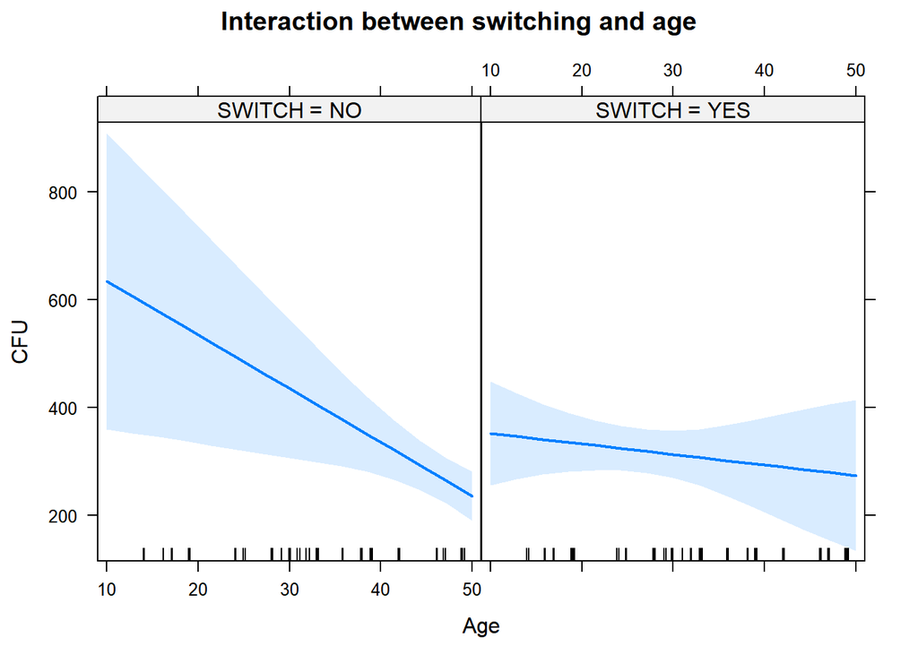

```r
plot(effect("SWITCH:AGE",
            glm4,
            #xlevels=list(CALC_ARRIVAL=900:2000),
            multiline=TRUE),
     main = "Interaction between switching and age",
     xlab = "Age",
     ylab = "CFU")
```

[output not shown]